# Assignment 6 - Unsupervised Machine Learning Techniques

Marko Konte

7/9/2019

##Introduction

In this section we will be going through exmaples of unsupervised models on the healthcare dataset.

First, lets read the data and convert the key cost based variables to numeric.

## Capping and Flooring

```r
#Function for capping and flooring of data
#Capping and flooring
fun <- function(x){
  quantiles <- quantile( x, c(.05, .95 ) )
  x[ x < quantiles[1] ] <- quantiles[1]
  x[ x > quantiles[2] ] <- quantiles[2]
  x
}

#Function to Scale the data
scale_this <- function(x){
  (x - mean(x, na.rm=TRUE)) / sd(x, na.rm=TRUE)
}

#Applying capping and flooring to data
payment <- payment %>% dplyr::mutate(Total.Discharges = fun(Total.Discharges),
                                     Average.Covered.Charges = fun(Average.Covered.Charges),
                                     Average.Total.Payments = fun(Average.Total.Payments),
                                     Average.Medicare.Payments = fun(Average.Medicare.Payments))
```

## EDA

In order to prepare the variables for inputting models to the dataset, we will make several modicafations with the kay cost based data points in the dataset. The process of creating the variables is at follows:

1. Summing all cost based variables. After capping and flooring the key data points we will sum each individual cost based variable. In order to get it prepared to run on a clustering model, we will scale then scale these figures.
2. Taking the differences from key variables. We will rely on total payments as a baseline and calculate the difference from medicare payments and covered charges. In addition, we will calculate the difference between covered charges and mediare per procedure and state.
3. Making key ratios from the cost based variables and total discharge. We will look at the ratio between covered charges and medicare to total payments. In addition, we identify the total payments per discharge, medicare payments per discharge, and covered payments per discharge

```
##    DRGState                           Provider.Name        Count
##  Length:162613      GOOD SAMARITAN HOSPITAL  :   478   Min.   :1.000
##  Class :character   MERCY MEDICAL CENTER     :   357   1st Qu.:1.000
##  Mode  :character   MERCY HOSPITAL           :   347   Median :1.000
##                     ST JOSEPH MEDICAL CENTER :   347   Mean   :1.003
##                     ST JOSEPH HOSPITAL       :   295   3rd Qu.:1.000
##                     ST FRANCIS MEDICAL CENTER:   277   Max.   :3.000
##                     (Other)                  :160512
##    PayMedDiff        CovMedDiff       TotCovDiff       PayMedDiffSc
##  Min.   :    0.0   Min.   : -9380   Min.   :-162498   Min.   :-8.1209
##  1st Qu.:  791.3   1st Qu.: 10764   1st Qu.: -32740   1st Qu.:-0.5557
##  Median :  963.4   Median : 18663   Median : -17551   Median :-0.2363
##  Mean   : 1197.9   Mean   : 25833   Mean   : -24635   Mean   : 0.0000
##  3rd Qu.: 1282.9   3rd Qu.: 34036   3rd Qu.:  -9745   3rd Qu.: 0.2469
##  Max.   :21067.5   Max.   :165339   Max.   :  14676   Max.   :11.8440
##
##   CovMedDiffSc      CovTotDiffSc
##  Min.   :-8.1974   Min.   :-10.3410
##  1st Qu.:-0.7071   1st Qu.: -0.5714
##  Median :-0.1382   Median :  0.1401
##  Mean   : 0.0000   Mean   :  0.0000
##  3rd Qu.: 0.5707   3rd Qu.:  0.7071
##  Max.   :10.3412   Max.   :  8.1974
##
```

##Extracting features to be used in Model and creating Training set

Next, we will take the features that were created from the dataset and create a training set to run various models on. In order to run the models, we will isolate all numeric variables and create the DRGState variables to be able to join the summarised values from above to the dataset. Since the models take a significant amount of computational power, we will use a lesser number of observations within the training set to run the models created.

```r
#Model set with without any splitting

FinalDB <- payment %>% mutate(DRGState = paste(Provider.State,
                                               DRG.Definition, sep="_"))

FinalDB <- select(FinalDB, Provider.Id, Provider.Name, Provider.Zip.Code, Average.Covered.Charges,
                  Average.Total.Payments, Average.Medicare.Payments, Total.Discharges,
                  DRGState)

#Train set setup
library(caTools)
split = sample.split(payment, SplitRatio = 0.1)
train = subset(payment, split == TRUE)
test = subset(payment, split == FALSE)

train <- train %>% mutate(DRGState = paste(Provider.State,
                                           DRG.Definition, sep="_"))

train <- select(train, Provider.Id, Provider.Name, Provider.Zip.Code,Average.Covered.Charges,
                Average.Total.Payments, Average.Medicare.Payments, Total.Discharges,
                DRGState)

#Scaled version of key numeric cost variables
train <- train %>% left_join(Scaled, by=c("DRGState", "Provider.Name"))

#Adding values from DIfferences Table
train <- train %>% left_join(TotPaymMed1Sc, by=c("DRGState","Provider.Name"))

#Adding scaled values from the percentages variables
train <- train %>% left_join(PercTotSc, by=c("DRGState","Provider.Name"))
```

##DBSCAN

This method takes the ability measure different clusters within the dataset by measuring the shortest distances between points using eucladian distance to identify nearest ones. The model has two key parameters that need to be set, eps identifies how close an observation needs to be to be within a cluster, while MinPts identifies how many observations need to be within that distance in order to be considered a cluster. If the model does not identify the MinPts number of data points within the eps distance in the matrix, it labels those points as ‘noise’. The model moves along the matrix calculating and searching for proximity and state counts of data to create a clusters until there are no more data points covered.

```r
#DBSCan

dbscanset <- select(train, ScTotPay, ScTotCov, ScTotMed, ScTotDis,
                           PayMedDiffSc, CovMedDiffSc, CovTotDiffSc,
                           ScMedPerc, ScCovPerc, ScMedPerDis,
                           ScTotPerDis, ScCovPerDis, ScDisPerc)

db <- fpc::dbscan(dbscanset, eps = 0.55, MinPts = 5)
db
```

```
## dbscan Pts=13589 MinPts=5 eps=0.55
##            0   1   2  3  4 5 6  7 8  9 10 11 12 13 14 15 16 17 18 19 20 21
## border 11282 390 278 18  5 5 2  7 5  8  2  2  7  3  3  4  6  4  6  6 13  7
## seed       0 491 359 15  6 2 3  6 3  4  2  1  4  1  1  1  3  3  2  4 12  3
## total  11282 881 637 33 11 7 5 13 8 12  4  3 11  4  4  5  9  7  8 10 25 10
##        22 23 24 25 26 27 28 29 30 31 32  33 34 35 36 37 38 39 40 41 42 43
## border  5  5  7  4  4  4  4  5  2  4  3  37  3  2  4  4  4  6  6  4  4  6
## seed    1  2  4  1  1  1  1  2  5  1 31 217 17 10  1  1  1  3  2  1  1  2
## total   6  7 11  5  5  5  5  7  7  5 34 254 20 12  5  5  5  9  8  5  5  8
##        44 45 46 47 48 49 50 51 52 53 54 55 56 57 58 59 60 61 62 63 64 65
## border  2  7  5  4  4  4  4  4  2  5  5  3  4  3  3  3  3  4  4  4  2  4
## seed    1  5  2  1  1  1  1  7  2  1  1  1  1  1  1  1  2  1  1  1  1  1
## total   3 12  7  5  5  5  5 11  4  6  6  4  5  4  4  4  5  5  5  5  3  5
##        66 67 68 69 70 71 72 73 74 75 76
## border  3  3  3  2  6  4  5  3  3  2  4
## seed    1  1  1  1  1  1  1  1  1  1  1
## total   4  4  4  3  7  5  6  4  4  3  5
```

```r
table(db$cluster)
```

```
##
##     0     1     2     3     4     5     6     7     8     9    10    11
## 11282   881   637    33    11     7     5    13     8    12     4     3
##    12    13    14    15    16    17    18    19    20    21    22    23
##    11     4     4     5     9     7     8    10    25    10     6     7
##    24    25    26    27    28    29    30    31    32    33    34    35
##    11     5     5     5     5     7     7     5    34   254    20    12
##    36    37    38    39    40    41    42    43    44    45    46    47
##     5     5     5     9     8     5     5     8     3    12     7     5
##    48    49    50    51    52    53    54    55    56    57    58    59
##     5     5     5    11     4     6     6     4     5     4     4     4
##    60    61    62    63    64    65    66    67    68    69    70    71
##     5     5     5     5     3     5     4     4     4     3     7     5
##    72    73    74    75    76
##     6     4     4     3     5
```

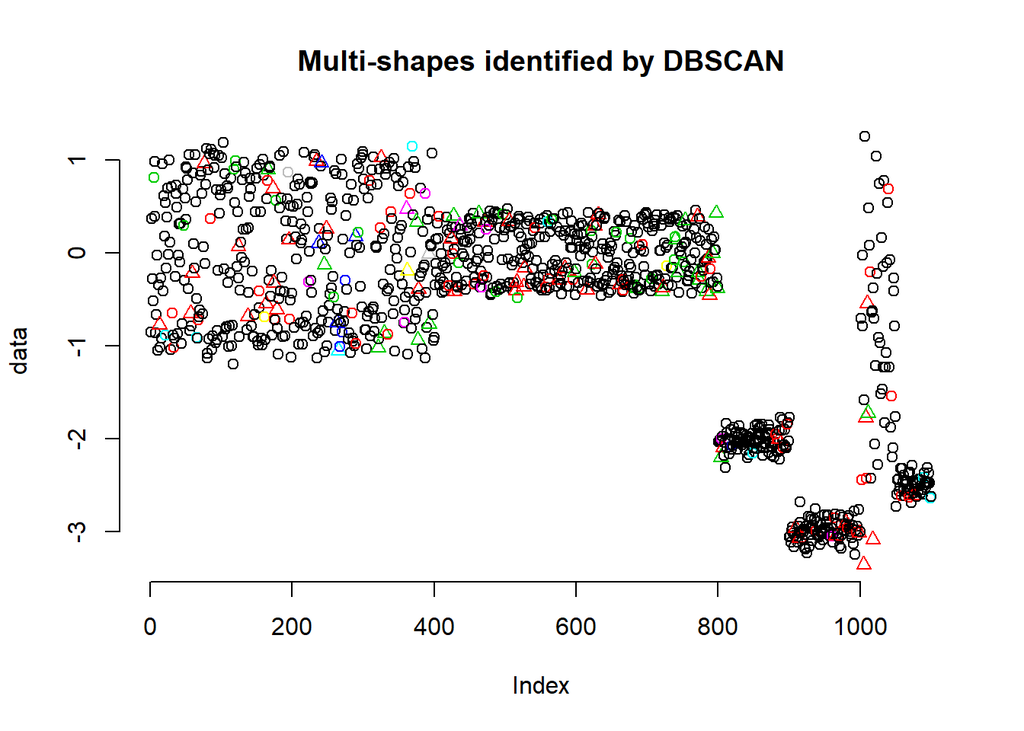

```r
# Plot DBSCAN results
data("multishapes")
plot(db,multishapes$y, main = "Multi-shapes identified by DBSCAN", frame = FALSE)
```

```r
#Running a PCA Analysis on the DBSCAN results
dbsPCA <- prcomp(dbscanset)
dbsPCA
```

```
## Standard deviations (1, .., p=13):
##  [1] 1.97033830 1.87361350 1.40412744 1.22132042 0.92773334 0.68541590
##  [7] 0.64747118 0.47467274 0.26121758 0.16449006 0.13693863 0.05492361
## [13] 0.04470378
##
## Rotation (n x k) = (13 x 13):
##                      PC1         PC2          PC3         PC4         PC5
## ScTotPay     -0.20443234 -0.07390368  0.627461421 -0.12262199  0.06424149
## ScTotCov     -0.37724262 -0.33847389 -0.011871220  0.04454613  0.08815042
## ScTotMed     -0.20219453 -0.02399144  0.612351175  0.16861901  0.14036276
## ScTotDis      0.11679392 -0.29200936  0.179066690  0.19538948 -0.62913886
## PayMedDiffSc -0.04747144 -0.14540839  0.137602126 -0.68371528 -0.19598850
## CovMedDiffSc -0.35842316 -0.34786976 -0.107915240  0.01850314  0.06779850
## CovTotDiffSc  0.35906055  0.34259829  0.117066234 -0.06412915 -0.08038107
## ScMedPerc    -0.14055413  0.21697690  0.087539948  0.62962674 -0.04101008
## ScCovPerc    -0.25693744 -0.24217668 -0.345866399  0.08285137 -0.01398517
## ScMedPerDis  -0.32190860  0.37786971 -0.002598515 -0.04353215 -0.29777133
## ScTotPerDis  -0.32095423  0.37185211 -0.008043406 -0.12043368 -0.28675556
## ScCovPerDis  -0.40433011  0.22971507 -0.162720957 -0.06621431 -0.26699221
## ScDisPerc     0.21409083 -0.30828723  0.031487843  0.14272606 -0.52825857
##                      PC6         PC7         PC8           PC9
## ScTotPay     -0.20580299  0.01508064 -0.01798512  0.0009861949
## ScTotCov      0.19099422 -0.10949703  0.04006708  0.0554911234
## ScTotMed     -0.26265023 -0.06374579  0.07628518 -0.0198639570
## ScTotDis      0.17488846  0.49655351  0.39690061  0.0115077955
## PayMedDiffSc  0.17316961  0.26668550 -0.54719183 -0.0077336464
## CovMedDiffSc  0.25324256 -0.11157684  0.02684613 -0.0155873689
## CovTotDiffSc -0.24788190  0.12634536 -0.04643048  0.0188043331
## ScMedPerc     0.25400670  0.24383292 -0.62685660 -0.0368518450
## ScCovPerc    -0.70018454  0.35474207 -0.15426896  0.3282660210
## ScMedPerDis   0.07288224 -0.14177469  0.05880118  0.3732135389
## ScTotPerDis   0.06049741 -0.14200353  0.11490150  0.3513019537
## ScCovPerDis  -0.22629507  0.02542682  0.06199193 -0.7896468442
## ScDisPerc    -0.22598952 -0.64141433 -0.30850477 -0.0193956772
##                      PC10          PC11          PC12         PC13
## ScTotPay      0.681031470 -0.1580990538  0.0878497871  0.021241764
## ScTotCov      0.111446684  0.8170921362 -0.0006818892  0.003773206
## ScTotMed     -0.669593361  0.0230842434 -0.0829307733 -0.020134731
## ScTotDis     -0.014548167  0.0001754349 -0.0017935594  0.001815141
## PayMedDiffSc -0.222887179  0.0311754109 -0.0003717881  0.023497206
## CovMedDiffSc -0.005585780 -0.3902856466 -0.2610430149 -0.660221449
## CovTotDiffSc  0.097507401  0.3869278325 -0.2573164400 -0.651209024
## ScMedPerc     0.077245120 -0.0077583986 -0.0526977987  0.017477120
## ScCovPerc     0.001134733 -0.0306738633 -0.0065529231  0.002676880
## ScMedPerDis  -0.084265200 -0.0086594684  0.6479142563 -0.260563745
## ScTotPerDis   0.050327264 -0.0280571528 -0.6540965651  0.265167802
## ScCovPerDis   0.008926980  0.0442516311  0.0165513732 -0.006921181
## ScDisPerc     0.017607420  0.0016738310 -0.0177968807  0.006342621
```

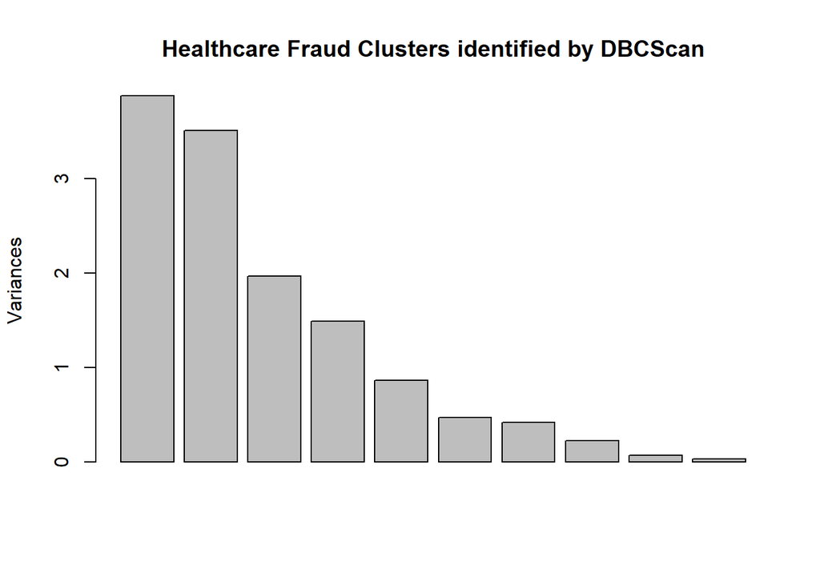

```r
plot(dbsPCA, main = "Healthcare Fraud Clusters identified by DBCScan", frame = FALSE)
```

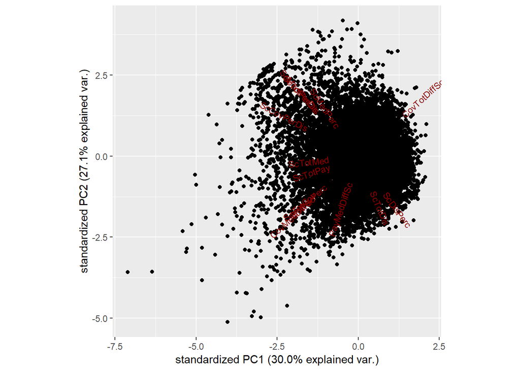

```r
ggbiplot::ggbiplot(dbsPCA)
```

```r
#Ranking per cluster instances
db_with_cluster = dbscanset
db_with_cluster['dbscan_cluster'] = db$cluster
head(db_with_cluster)
```

```
##      ScTotPay   ScTotCov   ScTotMed     ScTotDis PayMedDiffSc CovMedDiffSc
## 1  0.58814494 -0.1747557  1.2701794  3.178616791   -0.7936441   -0.2055095
## 2 -0.05296899  1.1499543 -0.2583822 -0.324018022    0.2898706    1.1537808
## 3  0.94753286  2.3010818  1.2798491 -0.483210868   -0.4962743    2.1386314
## 4 -1.00962062 -0.6801982 -1.9666014 -0.746780432    1.7295769   -0.4685600
## 5 -0.51330592 -0.2110561 -0.3019513 -0.162055332   -0.8544554   -0.2043808
## 6 -0.52999017 -0.8168167 -0.4104991 -0.003482014   -0.3207275   -0.8074198
##   CovTotDiffSc   ScMedPerc ScCovPerc ScMedPerDis ScTotPerDis ScCovPerDis
## 1    0.1922760  0.16213069 0.5238547  -0.8992774  -0.9457863  -0.8023285
## 2   -1.1466661 -0.81489981 3.3589111  -0.5478604  -0.5205751   0.3608331
## 3   -2.1222803  0.28425950 1.8449910   0.2644357   0.2726267   1.3334815
## 4    0.5471837 -3.01321844 0.3197307  -0.2255786   0.1436278   0.3161210
## 5    0.1936065 -0.20425575 0.2346790  -0.6174893  -0.6292392  -0.5029146
## 6    0.7921358  0.04000187 0.9264327  -0.2636181  -0.2617107   0.1081624
##    ScDisPerc dbscan_cluster
## 1  2.4183292              0
## 2  0.8658215              0
## 3 -0.6866863              0
## 4 -0.6866863              0
## 5  0.8658215              2
## 6 -0.6866863              0
```

```r
db_with_clusterT <- db_with_cluster[,9:14]
datatable(
    db_with_clusterT,
    rownames = FALSE,
    colnames=c("Cove/Tot","Med/Discharge", "Pay/Discharge","Cov/Discharge","Discharge%","Cluster"),
    options = list(columnDefs=list(list(className = 'dt-center', targets = 0:5)))
    )
```

| Cove/Tot | Med/Discharge | Pay/Discharge | Cov/Discharge | Discharge% | Cluster |
| --- | --- | --- | --- | --- | --- |
| 0.523854731978347 | -0.899277444951464 | -0.945786320906781 | -0.802328543490244 | 2.41832921478592 | 0 |
| 3.35891105934014 | -0.547860378314688 | -0.520575129044354 | 0.360833147588866 | 0.865821452858478 | 0 |
| 1.84499098052894 | 0.264435656188101 | 0.27262672814837 | 1.33348147278112 | -0.686686309068962 | 0 |
| 0.319730676408298 | -0.225578615080692 | 0.143627802609507 | 0.316121039957309 | -0.686686309068962 | 0 |
| 0.234678986587445 | -0.617489348541851 | -0.629239248586943 | -0.502914624230699 | 0.865821452858478 | 2 |
| 0.926432730463722 | -0.263618120279355 | -0.261710737938379 | 0.108162439792305 | -0.686686309068962 | 0 |
| 1.76560940336281 | -0.661790112247159 | -0.705870271751879 | -0.330368180249929 | 0.865821452858478 | 0 |
| 2.65581709015441 | 0.613115388703881 | 0.624961903634945 | 2.51559085850683 | -0.686686309068962 | 0 |
| -0.298311602956572 | 0.271986922728778 | 1.75576775583399 | 1.24014807822601 | -0.686686309068962 | 0 |
| 3.26251914420984 | 0.0915745796277598 | 0.132853821591595 | 1.83377295213583 | -0.686686309068962 | 0 |

[output cut: 13579 more lines]

```r
#DBSCAN 2 #Too much computing time to include in an RMarkdown for submittal
#dbscanset2 <- select(train, ScTotPay, ScTotCov, ScTotMed, ScTotDis,
                     #PayMedDiffSc, CovMedDiffSc, CovTotDiffSc,
                     #MedPerDis, ScMedPerc, ScCovPerc, ScMedPerc, ScMedPerDis,
                     #ScTotPerDis, ScCovPerDis, ScDisPerc, ScCovPerc)

#dbs2 <- fpc::dbscan(dbscanset2, eps = 0.01, MinPts = 99)
#summary(dbs2$cluster)

#table(dbs2$cluster)
#plot(dbs2,multishapes, main = "Multi-shapes identified by DBSCAN", frame = FALSE)
#plot(dbs2,multishapes$y, main = "Multi-shapes identified by DBSCAN", frame = FALSE)
```

*Outliers?*

*Insight*

There would need to be further analysis of the variables which were clear outlier within the plotted data from the DBScan model. In order to make further and meangingful insightful analysis however, the model would need to be run with better suitted parameters on EPS and MinPts. The outliers within the identified clusters are focused on those that are outside of the main groupings in od the model (seen in the plot chart), whereas the ‘noise’ that is close to the large groupings would presumbly be captured within a cluster with a higher eps or MinPts parameter.

##Meanshift

The meanshift model takes a similar approach to DBSCAN but instead of using centerpoints, it moves along the dense areas of the dataset in order to identify which items belong to a cluster. It is considered a ‘hill climbing’ algorithim since it begins to calculate the clusters starting at a random point and then calculating which are the nearest features within the dataset. Since it looks for datapoints which are near each other, the model naturally moves towards the denser regions of where the data lies in the matrix. Once density within a window of points decreases, the model completes that cluster and moves to repeat this process on other, non covered data points in the set.

```r
library(meanShiftR)

meanshift <- select(train, ScTotPay, ScTotCov, ScTotMed, ScTotDis,
                     PayMedDiffSc, CovMedDiffSc, CovTotDiffSc,
                     ScMedPerc, ScCovPerc, ScMedPerc, ScMedPerDis,
                     ScTotPerDis, ScCovPerDis, ScDisPerc, ScCovPerc)


#meanshift <- meanShift(meanshift, trainData = meanshift, nNeighbors = NROW(meanshift), kernelType = "NORMAL",
                       #bandwidth = rep(1, NCOL(trainData)))
```

**Summary**

This was an incomplete model due to the inability to get the right syntax to work with the model. First the type of R version that was ran was not supportive of the initial, then there were issues with establishing correct syntax with meanShiftR to make insightful.

##K-Means Clustering

K-means is perhaps the simplest of the three approaches. Generallly considered the biggest weakness with the KMM approach is that the user must specify how many clusters should be counted from the dataset. This is a particularly large weakness for this dataset since there are so many observations within it. The model calculates points by measuring the mean distance of all points around them. Once it has identified the center value (where the mean is equadistant from all other points in the cluster) within the number of clusters that was specified by the user, the model is completed and the clusters identified.

```r
#Kmeans

km <- select(train, ScTotPay, ScTotCov, ScTotMed, ScTotDis,
                           PayMedDiffSc, CovMedDiffSc, CovTotDiffSc,
                           ScMedPerc, ScCovPerc, ScMedPerDis,
                           ScTotPerDis, ScCovPerDis, ScDisPerc)

kmeans <- kmeans(km, 5, nstart = 30)

#Breaking down the number of instances per cluster
table(kmeans$cluster)
```

```
##
##    1    2    3    4    5
## 1080 4853 2589 3835 1232
```

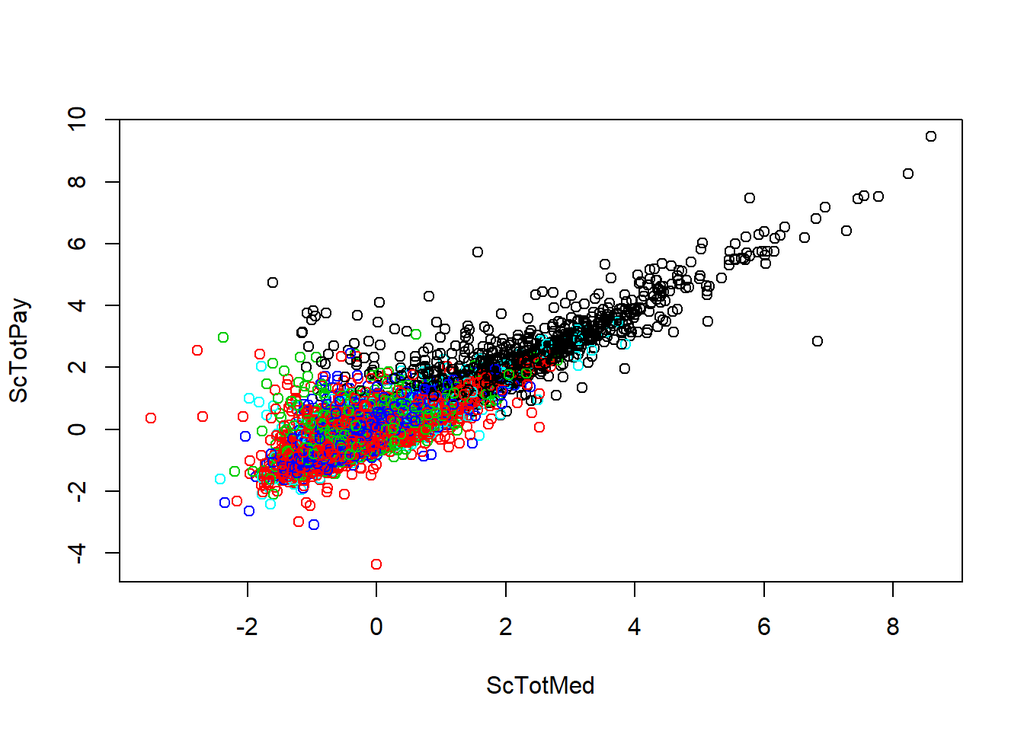

```r
#Medicare and Total Pay scaled
plot(km[c("ScTotMed", "ScTotPay")], col = kmeans$cluster)
```

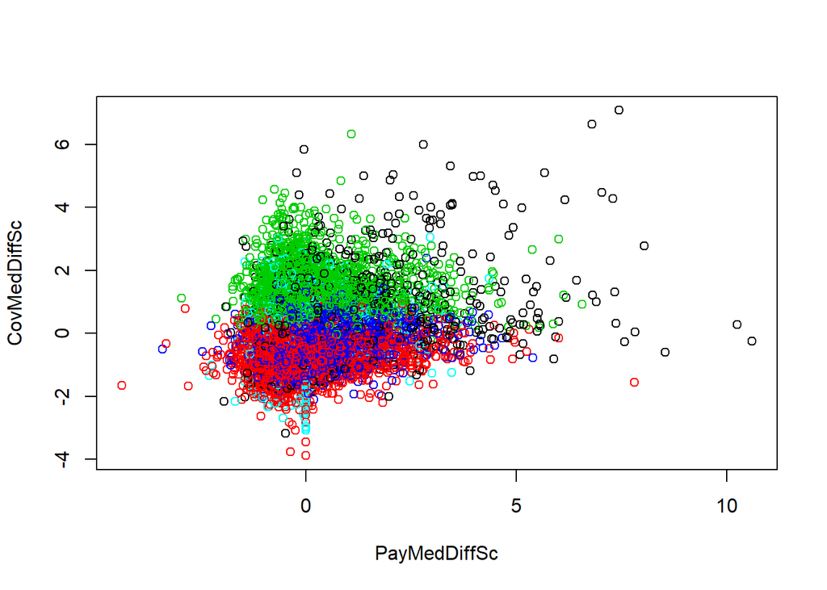

```r
#Payment - Meidcare and Covered Charges - Medicare
plot(km[c("PayMedDiffSc", "CovMedDiffSc")], col = kmeans$cluster)
```

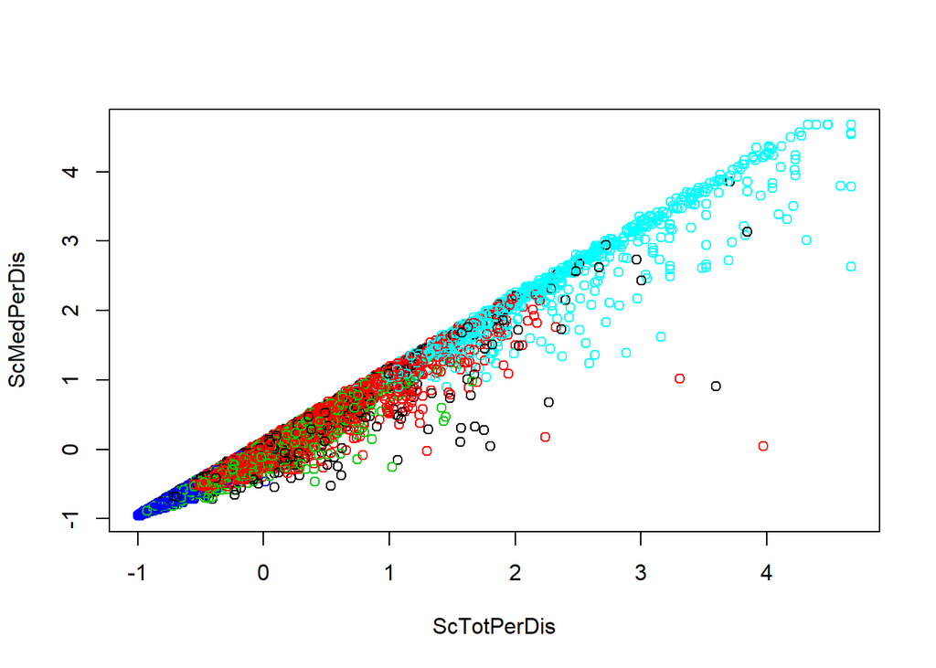

```r
#Payment per discharge and Medicare per discharge
plot(km[c("ScTotPerDis", "ScMedPerDis")], col = kmeans$cluster)
```

```r
#Running PCA analysis based on KMeans
kmeansPCA <- prcomp(km)
summary(kmeansPCA)
```

```
## Importance of components:
##                           PC1    PC2    PC3    PC4     PC5     PC6     PC7
## Standard deviation     1.9703 1.8736 1.4041 1.2213 0.92773 0.68542 0.64747
## Proportion of Variance 0.2998 0.2711 0.1522 0.1152 0.06646 0.03628 0.03237
## Cumulative Proportion  0.2998 0.5709 0.7231 0.8383 0.90476 0.94104 0.97341
##                           PC8     PC9    PC10    PC11    PC12    PC13
## Standard deviation     0.4747 0.26122 0.16449 0.13694 0.05492 0.04470
## Proportion of Variance 0.0174 0.00527 0.00209 0.00145 0.00023 0.00015
## Cumulative Proportion  0.9908 0.99608 0.99816 0.99961 0.99985 1.00000
```

```r
kmeansPCA <- kmeansPCA$x[,1:2]
plot(kmeansPCA, main = "Healthcare Fraud Clusters identified by K-means", frame = FALSE)
```

[output not shown]

```r
#Kmeans 2

km2 <- select(train, ScTotPay, ScTotCov, ScTotMed, ScTotDis,
                           PayMedDiffSc, CovMedDiffSc, CovTotDiffSc,
                           ScMedPerc, ScCovPerc, ScMedPerDis,
                           ScTotPerDis, ScCovPerDis, ScDisPerc)

kmeans2 <- kmeans(km2, 3, nstart = 50)
#Breaking down the number of instances per cluster
table(kmeans2$cluster)
```

```
##
##    1    2    3
## 7927 3688 1974
```

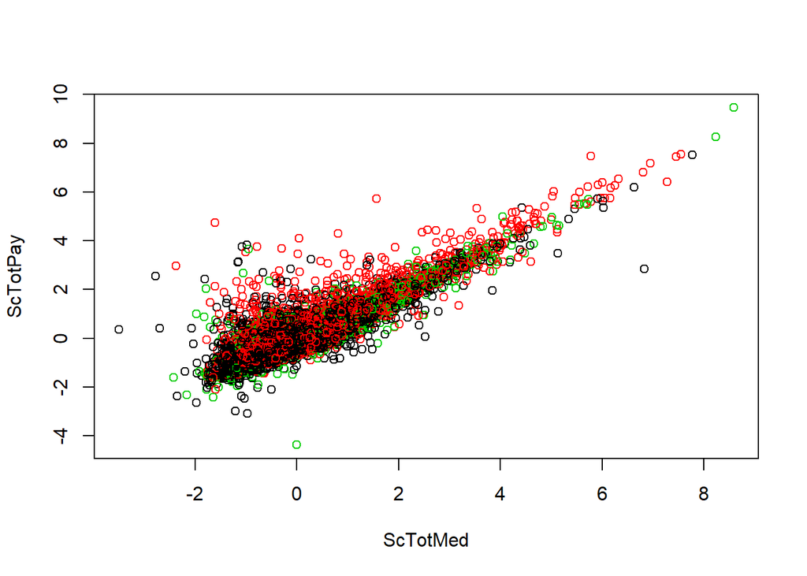

```r
#Medicare and Total Pay scaled
plot(km2[c("ScTotMed", "ScTotPay")], col = kmeans2$cluster)
```

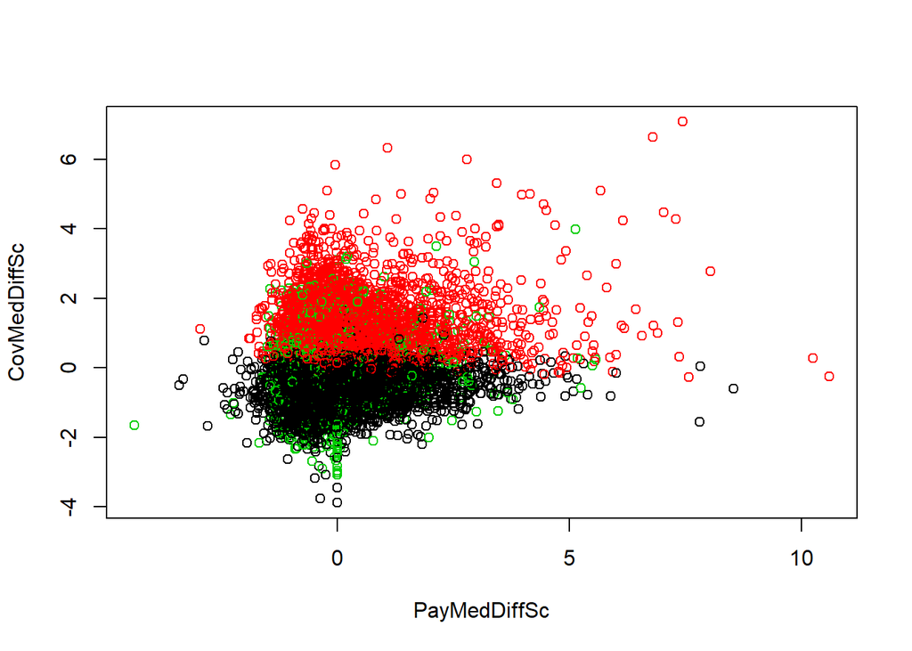

```r
#Payment - Meidcare and Covered Charges - Medicare
plot(km2[c("PayMedDiffSc", "CovMedDiffSc")], col = kmeans2$cluster)
```

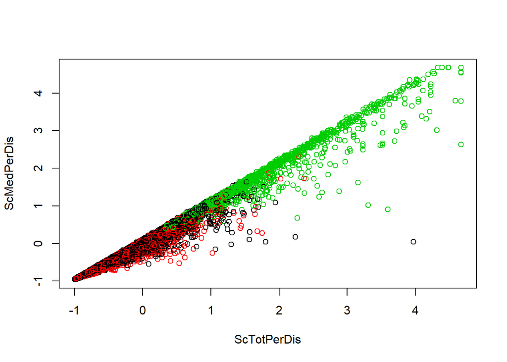

```r
#Payment per discharge and Medicare per discharge
plot(km2[c("ScTotPerDis", "ScMedPerDis")], col = kmeans2$cluster)
```

```r
#Running PCA analysis based on KMeans
kmeansPCA2 <- prcomp(km2)
summary(kmeansPCA2)
```

```
## Importance of components:
##                           PC1    PC2    PC3    PC4     PC5     PC6     PC7
## Standard deviation     1.9703 1.8736 1.4041 1.2213 0.92773 0.68542 0.64747
## Proportion of Variance 0.2998 0.2711 0.1522 0.1152 0.06646 0.03628 0.03237
## Cumulative Proportion  0.2998 0.5709 0.7231 0.8383 0.90476 0.94104 0.97341
##                           PC8     PC9    PC10    PC11    PC12    PC13
## Standard deviation     0.4747 0.26122 0.16449 0.13694 0.05492 0.04470
## Proportion of Variance 0.0174 0.00527 0.00209 0.00145 0.00023 0.00015
## Cumulative Proportion  0.9908 0.99608 0.99816 0.99961 0.99985 1.00000
```

```r
kmeansPCA2 <- kmeansPCA2$x[,1:2]
plot(kmeansPCA2, main = "Healthcare Fraud Clusters identified by K-means", frame = FALSE)
```

[output not shown]

```r
#Kmeans 3

km3 <- select(train, ScTotPay, ScTotCov, ScTotMed, ScTotDis,
                           PayMedDiffSc, CovMedDiffSc, CovTotDiffSc,
                           ScMedPerc, ScCovPerc, ScMedPerDis,
                           ScTotPerDis, ScCovPerDis, ScDisPerc)

kmeans3 <- kmeans(km3, 7, nstart = 50)

summary(kmeans3$centers)
```

```
##     ScTotPay          ScTotCov           ScTotMed          ScTotDis
##  Min.   :-0.4588   Min.   :-0.68603   Min.   :-0.4536   Min.   :-0.64216
##  1st Qu.:-0.2446   1st Qu.:-0.16990   1st Qu.:-0.3071   1st Qu.:-0.37658
##  Median : 0.1537   Median : 0.06663   Median :-0.1331   Median :-0.07340
##  Mean   : 0.6101   Mean   : 0.41615   Mean   : 0.5039   Mean   : 0.02219
##  3rd Qu.: 1.0729   3rd Qu.: 0.69576   3rd Qu.: 0.9844   3rd Qu.: 0.38091
##  Max.   : 2.9194   Max.   : 2.48076   Max.   : 2.7599   Max.   : 0.86225
##   PayMedDiffSc      CovMedDiffSc      CovTotDiffSc        ScMedPerc
##  Min.   :-0.3151   Min.   :-0.6503   Min.   :-2.16072   Min.   :-1.98041
##  1st Qu.:-0.1834   1st Qu.:-0.3065   1st Qu.:-0.72254   1st Qu.:-0.11892
##  Median :-0.1298   Median : 0.1401   Median : 0.01802   Median : 0.19638
##  Mean   : 0.3737   Mean   : 0.3562   Mean   :-0.33691   Mean   :-0.04335
##  3rd Qu.: 0.5491   3rd Qu.: 0.7086   3rd Qu.: 0.29752   3rd Qu.: 0.43213
##  Max.   : 2.3292   Max.   : 2.1996   Max.   : 0.63437   Max.   : 0.85419
##    ScCovPerc         ScMedPerDis        ScTotPerDis
##  Min.   :-0.61433   Min.   :-0.74065   Min.   :-0.76581
##  1st Qu.:-0.32894   1st Qu.:-0.22732   1st Qu.:-0.11481
##  Median :-0.16636   Median : 0.08281   Median : 0.07355
##  Mean   : 0.06513   Mean   : 0.23529   Mean   : 0.24979
##  3rd Qu.: 0.30669   3rd Qu.: 0.12474   3rd Qu.: 0.10338
##  Max.   : 1.28113   Max.   : 2.51003   Max.   : 2.46368
##   ScCovPerDis         ScDisPerc
##  Min.   :-0.70553   Min.   :-0.68669
##  1st Qu.:-0.16996   1st Qu.:-0.52934
##  Median :-0.09769   Median :-0.29376
##  Mean   : 0.25854   Mean   :-0.13795
##  3rd Qu.: 0.27476   3rd Qu.:-0.07821
##  Max.   : 2.40338   Max.   : 1.22991
```

```r
#Breaking down the number of instances per cluster
table(kmeans3$cluster)
```

```
##
##    1    2    3    4    5    6    7
## 2409 1143  343  889 4012 3569 1224
```

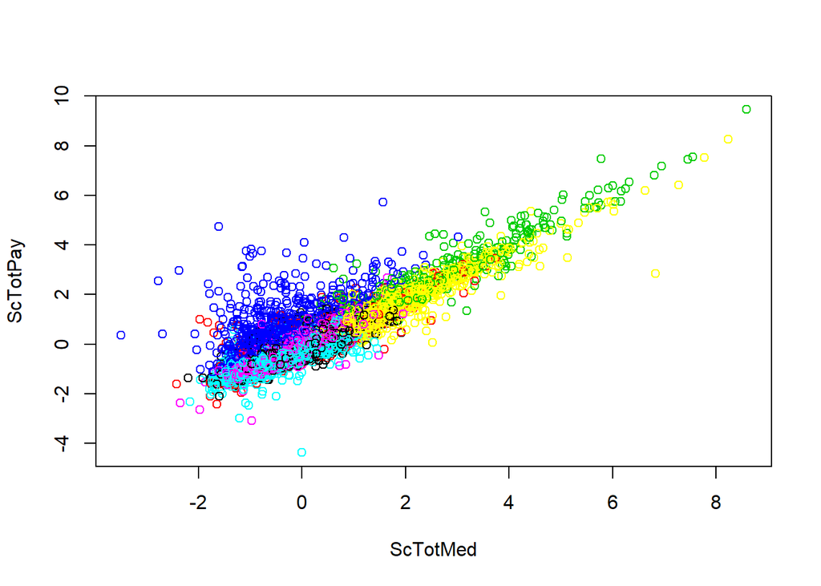

```r
#Medicare and Total Pay scaled
plot(km3[c("ScTotMed", "ScTotPay")], col = kmeans3$cluster)
```

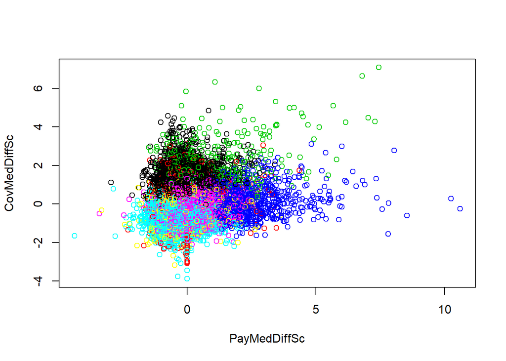

```r
#Payment - Meidcare and Covered Charges - Medicare
plot(km3[c("PayMedDiffSc", "CovMedDiffSc")], col = kmeans3$cluster)
```

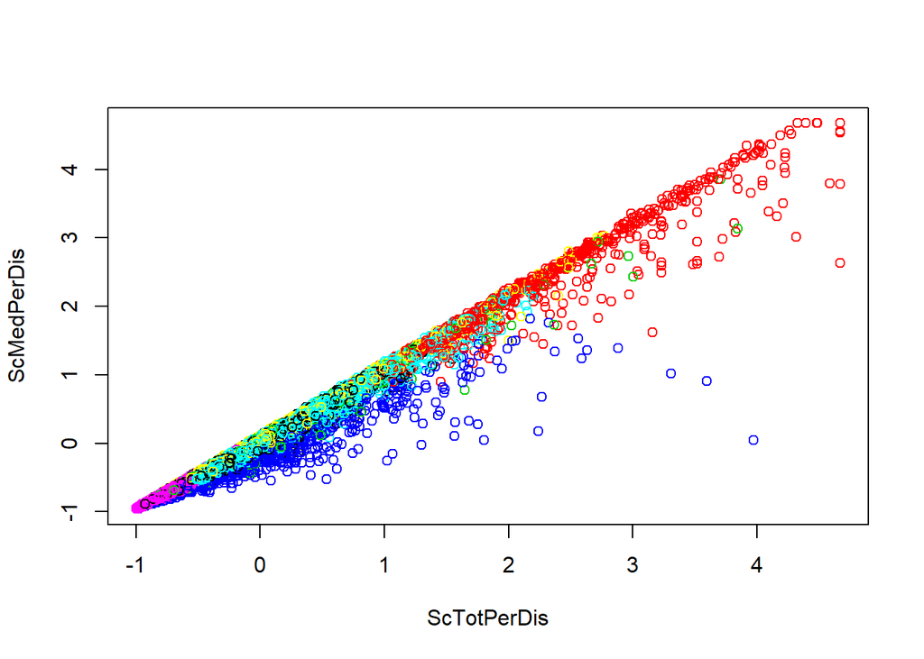

```r
#Payment per discharge and Medicare per discharge
plot(km3[c("ScTotPerDis", "ScMedPerDis")], col = kmeans3$cluster)
```

```r
#Running PCA analysis based on KMeans
kmeansPCA3 <- prcomp(km3)
kmeansPCA3 <- kmeansPCA3$x[,1:2]
plot(kmeansPCA3, main = "Healthcare Fraud Clusters identified by K-means", frame = FALSE)
```

[output not shown]

```r
cluster.stats(kmeans$cluster, kmeans2$cluster, kmeans3$cluster)
```

```
## $n
## [1] 13589
##
## $cluster.number
## [1] 3
##
## $cluster.size
## [1] 7927 3688 1974
##
## $min.cluster.size
## [1] 1974
##
## $noisen
## [1] 0
##
## $diameter
## [1] 5 5 5
##
## $average.distance
## [1] 2.947383 2.946633 2.947170
##
## $median.distance
## [1] 3 3 3
##
## $separation
## [1] 1 1 1
##
## $average.toother
## [1] 2.947216 2.947477 2.948017
##
## $separation.matrix
##      [,1] [,2] [,3]
## [1,]    0    1    1
## [2,]    1    0    1
## [3,]    1    1    0
##
## $ave.between.matrix
##          [,1]     [,2]     [,3]
## [1,] 0.000000 2.947065 2.947499
## [2,] 2.947065 0.000000 2.949132
```

[output cut: 53 more lines]

```
##
## $cwidegap
## [1] 1 1 1
##
## $widestgap
## [1] 1
##
## $sindex
## [1] 1
##
## $corrected.rand
## [1] 0.3120422
##
## $vi
## [1] 1.603929
```

**Summary**

*outliers* Different sections of variables gathered and added to the dataset tended to cluster together, therefore seing the irregular instances within those groupings would cause alarm as to potential fraudulent instances. For example, between the clustered relatinship of total payment and medicare payment could be used to identify transactions that were not within the norm.

*Insight*

Clusters which were led by medicare per discharge were highly correlated and in the same cluster as payment and covered cost per discharge. Outliers around this cluster of variable.

##Conclusion

Meanshift was an incomplete part of this analysis. The syntax could not be corrected in order to provide insightful analysis.

Kmeans was the most flexible in the ease with which computation could be completed, however the amount of parameters that are chosen by the user tends to make it the least reliable from an unsupervised model perspective.